# Introduction to tidyverse. Day 2.

2022-05-26

# 1 Introduction into tidyverse

From the official website [tidyverse.org](https://www.tidyverse.org/):

*“The tidyverse is an opinionated collection of R packages designed for data science. All packages share an underlying design philosophy, grammar, and data structures.”*

The most useful thing when learning the tidyverse is looking into their cheat sheets that include all important information about the specific package. For example, [this is a cheat sheet for a dplyr package](https://github.com/rstudio/cheatsheets/blob/main/data-transformation.pdf).

*Remember, you always have to load library if you want to use some functions from there.*

## 1.1 Install the complete tidyverse

```r
install.packages("tidyverse")
```

You can see what is installed using the command:

```r
library(tidyverse)
```

You can update all packages using the function `tidyverse_update()`.

## 1.2 A tibble

Remember how we created the data frames using `data.frame()` function? In tidyverse, the data frames are called **tibbles**. They are much like the regular data frames, except **printing** and **subsetting**:

Tibbles have a refined print method that shows only the first 10 rows, and all the columns that fit on screen. This makes it much easier to work with large data. In addition to its name, each column reports its type, a nice feature borrowed from `str()`:

```r
library(tibble)

tibble(
  id = seq(1:5),
  rock_name = c("charnockite", "pyroxenite", "dunite", "volynite", "anorthosite"),
  is.altered = c(TRUE, FALSE, FALSE, FALSE, FALSE)
)
```

```
## # A tibble: 5 × 3
##      id rock_name   is.altered
##   <int> <chr>       <lgl>
## 1     1 charnockite TRUE
## 2     2 pyroxenite  FALSE
## 3     3 dunite      FALSE
## 4     4 volynite    FALSE
## 5     5 anorthosite FALSE
```

You can convert a data frame into tibble by using function `as_tibble()`

```r
library(tibble)

df = data.frame(
  id = seq(1:5),
  rock_name = c("charnockite", "pyroxenite", "dunite", "volynite", "anorthosite"),
  is.altered = c(TRUE, FALSE, FALSE, FALSE, FALSE)
)

as_tibble(df)
```

```
## # A tibble: 5 × 3
##      id rock_name   is.altered
##   <int> <fct>       <lgl>
## 1     1 charnockite TRUE
## 2     2 pyroxenite  FALSE
## 3     3 dunite      FALSE
## 4     4 volynite    FALSE
## 5     5 anorthosite FALSE
```

# 2 Importing the data using `readr` package

A tidyverse has a separate package for importing the data. Yesterday, we used base function to load the data frame - `read.table()`. However, the tidyverse’ package `readr` is much more flexible! Check [readr](https://readr.tidyverse.org/) documentation and a cheatsheet to know more.

```r
library(readr)
library(knitr)

initial_data <- readr::read_csv('./data/raw_data/mafic_dykes.csv', col_names=TRUE)
```

```
## ──────────────────────────────────────────────────────── Delimiter: "," chr
## (22): specimen, location, country_rocks, analysis_type, rock_type, notes... dbl
## (46): SiO2, Al2O3, MgO, CaO, Na2O, K2O, TiO2, P2O5, MnO, Cr2O3, Ba, Sc, ...
```

```r
kable(initial_data[5:10,], caption='A sample table of XRF and ICP analyses of mafic dykes.')
```

A sample table of XRF and ICP analyses of mafic dykes.

| specimen | location | country_rocks | analysis_type | rock_type | notes | SiO2 | Al2O3 | Fe2O3 | MgO | CaO | Na2O | K2O | TiO2 | P2O5 | MnO | Cr2O3 | Ba | Ni…19 | Sc | LOI | Sum | Be | Co | Cs | Ga | Hf | Nb | Rb | Sn | … |
| --- | --- | --- | --- | --- | --- | --- | --- | --- | --- | --- | --- | --- | --- | --- | --- | --- | --- | --- | --- | --- | --- | --- | --- | --- | --- | --- | --- | --- | --- | --- |
| 0435 | Barchans | Paleogene granites | XRF | basalt | NA | 51.0700 | 16.5000 | 10.01 | 5.9300 | 9.1300 | 2.4200 | 2.2600 | 0.7780 | 0.1580 | 0.3730 | NA | NA | NA | NA | 1.49 | NA | NA | NA | NA | NA | NA | NA | NA | NA | … |
| 0440 | Barchans | Paleogene granites | XRF | basalt | NA | 52.1500 | 15.6300 | 10.23 | 5.3600 | 8.1000 | 3.3700 | 1.9400 | 0.7630 | 0.1540 | 0.4280 | NA | NA | NA | NA | 2.07 | NA | NA | NA | NA | NA | NA | NA | NA | NA | … |
| 17-100А-3 | Petermann | NA | XRF | metadiabase | NA | 47.8292 | 17.5616 | 10.2098 | 6.0954 | 9.9444 | 2.6407 | 0.5797 | 1.0659 | 0.1581 | 0.1634 | NA | 151 | 38 | NA | 1.97 | NA | NA | NA | NA | 19.0 | NA | 0.0 | 23.0 | NA | … |
| 17-10А-1 | Barchan S | Paleogene granites | XRF | basalt | NA | 50.3748 | 15.4264 | 10.232 | 7.7696 | 7.7121 | 1.9691 | 1.8989 | 0.7263 | 0.1209 | 0.3736 | NA | 158 | 65 | NA | 1.67 | NA | NA | NA | NA | 16.0 | NA | 0.0 | 107.0 | NA | … |
| 17-10A-1 | Barchans | granites | ICP | basalt | NA | 50.8900 | 16.0100 | 9.60 | 7.5700 | 8.0200 | 1.9900 | 2.0400 | 0.7200 | 0.1300 | 0.4100 | 0.053 | 168 | 93 | 28 | 2.30 | 99.76 | <1 | 26.9 | 7.9 | 15.6 | 1.7 | 1.4 | 115.9 | 2 | … |
| 17-114А-2 | Forge | granites | XRF | porphyritic diabase | NA | 44.2402 | 17.1863 | 9.871 | 7.2492 | 8.6993 | 3.1741 | 1.1960 | 0.8732 | 0.1117 | 0.1607 | NA | 570 | 34 | NA | 3.65 | NA | NA | NA | NA | 18.0 | NA | 0.0 | 45.0 | NA | … |

Note, the data frame imported is already a tibble and all data types are “guessed” under the hood 🙂.

# 3 Tidy data with `tidyr`

The package called [tidyr](https://tidyr.tidyverse.org/) is used to create tidy data representation.

The problem is that the same data may be represented in **multiple ways** using the table representation. Here are some examples with same data but different representations:

```r
library(tidyr)

tibble(
  id = paste0(seq(1:5), '.sample'),
  mineral = c('magnetite', 'ilmenite', 'ilmenite', 'Cr-spinel', 'hercynite'),
  city = c('Banska Bystrica', 'Bratislava', 'Banska Bystrica', 'Banska Bystrica', 'Banska Bystrica'),
  institution = c('SAV', 'Geological Institute', 'SAV', 'SAV', 'SAV'),
  n_analyses = c(30, 119, 40, 20, 10)
)
```

```
## # A tibble: 5 × 5
##   id       mineral   city            institution          n_analyses
##   <chr>    <chr>     <chr>           <chr>                     <dbl>
## 1 1.sample magnetite Banska Bystrica SAV                          30
## 2 2.sample ilmenite  Bratislava      Geological Institute        119
## 3 3.sample ilmenite  Banska Bystrica SAV                          40
## 4 4.sample Cr-spinel Banska Bystrica SAV                          20
## 5 5.sample hercynite Banska Bystrica SAV                          10
```

```r
tibble(
  id = paste0(seq(1:5), '.sample'),
  mineral = c('magnetite', 'ilmenite', 'ilmenite', 'Cr-spinel', 'hercynite'),
  lab = c('SAV, Banska Bystrica', 'Geological Institute, Bratislava', 'SAV, Banska Bystrica', 'SAV, Banska Bystrica', 'SAV, Banska Bystrica'),
  n_analyses = c(30, 119, 40, 20, 10)
)
```

```
## # A tibble: 5 × 4
##   id       mineral   lab                              n_analyses
##   <chr>    <chr>     <chr>                                 <dbl>
## 1 1.sample magnetite SAV, Banska Bystrica                     30
## 2 2.sample ilmenite  Geological Institute, Bratislava        119
## 3 3.sample ilmenite  SAV, Banska Bystrica                     40
## 4 4.sample Cr-spinel SAV, Banska Bystrica                     20
## 5 5.sample hercynite SAV, Banska Bystrica                     10
```

```r
tibble(
  city = c('Bratislava', 'Banska Bystrica'),
  institution = c('SAV', 'Geological Institute'),
  minerals = list(list('magnetite', 'ilmenite', 'ilmenite', 'Cr-spinel'), list('hercynite')),
  n_analyses = c(119, 100)
)
```

```
## # A tibble: 2 × 4
##   city            institution          minerals   n_analyses
##   <chr>           <chr>                <list>          <dbl>
## 1 Bratislava      SAV                  <list [4]>        119
## 2 Banska Bystrica Geological Institute <list [1]>        100
```

In order to make things clear, we’ll use next terminology:

1. **A variable is a column.**
2. **An observation is a row.**
3. **A cell in the table is a value.**

**tidyr** functions fall into five main categories. We will not dive into those, because they are a bit complicated.

## 3.1 Pivotting

Converts between long and wide forms. tidyr 1.0.0 introduces `pivot_longer()` and `pivot_wider()`. See `vignette("pivot")` for more details.

## 3.2 Rectangling

Turns deeply nested lists (as from JSON) into tidy tibbles. See `unnest_longer()`, `unnest_wider()`, `hoist()`, and `vignette("rectangle")` for more details.

## 3.3 Nesting

Converts grouped data to a form where each group becomes a single row containing a nested data frame, and unnesting does the opposite. See `nest()`, `unnest()`, and `vignette("nest")` for more details.

## 3.4 Splitting and combining character columns

Use `separate()` and `extract()` to pull a single character column into multiple columns; use `unite()` to combine multiple columns into a single character column.

As an example of what these functions may do, let’s look into the following:

```r
library(readr)
library(tidyr)
library(knitr)
library(dplyr)
initial_data <-readxl::read_xls('./data/raw_data/Chrysoberyl analysis database.xls')
kable(initial_data[1:5,], caption='A sample table of EPMA analyses of Be minerals.')
```

A sample table of EPMA analyses of Be minerals.

| Sample | analysis 1 | analysis 2 | analysis 3 | analysis 4 | analysis 5 | analysis 6 | analysis 7 | analysis 8 | analysis 9 | analysis 10 | analysis 11 | analysis 12 | analysis 13 | analysis 14 | analysis 15 | analysis 16 | analysis 17 | analysis 18 | analysis 19 | analysis 20 | analysis 21 | analysis 22 | analysis 23 | analysis 24 | analysis 25 | analysis 26 | analysis 27 | analysis 28 | analysis 29 | … |
| --- | --- | --- | --- | --- | --- | --- | --- | --- | --- | --- | --- | --- | --- | --- | --- | --- | --- | --- | --- | --- | --- | --- | --- | --- | --- | --- | --- | --- | --- | --- |
| Origin | Magmatic leucogranite | Magmatic leucogranite | Magmatic leucogranite | Magmatic leucogranite | Magmatic leucogranite | Magmatic leucogranite | Metamorphosed pegmatite | Metamorphosed pegmatite | Metamorphosed pegmatite | Metamorphosed pegmatite | Metamorphosed pegmatite | Metamorphosed pegmatite | Metamorphosed pegmatite | Metamorphosed pegmatite | Metamorphosed pegmatite | Metamorphosed pegmatite | Metamorphosed pegmatite | Metamorphosed pegmatite | Metamorphosed pegmatite | Metamorphosed pegmatite | Metamorphosed pegmatite | Metamorphosed pegmatite | Metamorphosed pegmatite | Metamorphosed pegmatite | Metamorphosed pegmatite | Metamorphosed pegmatite | Metamorphosed pegmatite | Metamorphosed pegmatite | Metamorphosed pegmatite | … |
| Reference | Merino et al. 2010 | Merino et al. 2013 | NA | NA | NA | Vignola et al. 2018 | Žáček, Vrána 2002 | NA | NA | NA | NA | NA | Beurlen et al. 2013 | NA | NA | NA | NA | NA | NA | NA | NA | NA | NA | NA | NA | NA | NA | NA | NA | … |
| SiO2 | 0.02 | 0.02 | 0.040000000000000001 | 0.02 | 0.11 | NA | 0 | 0 | 0 | 0 | 0 | 0 | 0 | 0 | 0 | 0 | 0 | 0 | 0 | 0 | 0 | 0 | 0 | 0 | 0 | 0 | 0 | 0 | 0 | … |
| TiO2 | 0.62 | 0.11 | 0.23000000000000001 | 0.54000000000000004 | 0.02 | 0.63 | 0 | 0 | 0.40000000000000002 | 0.23999999999999999 | 0.20000000000000001 | 0.10000000000000001 | 0 | 0 | 0 | 0 | 0 | 0 | 0 | 0 | 0 | 0 | 0 | 0 | 0 | 0 | 0 | 0 | 0 | … |
| Al2O3 | 79.629999999999995 | 78.629999999999995 | 80.359999999999999 | 78.260000000000005 | 79.140000000000001 | 81.480000000000004 | 76.890000000000001 | 77.299999999999997 | 75.480000000000004 | 74.650000000000006 | 74.469999999999999 | 74.980000000000004 | 79.920000000000002 | 80.319999999999993 | 79.489999999999995 | 79.959999999999994 | 80.590000000000003 | 79.75 | 80.439999999999998 | 79.890000000000001 | 79.599999999999994 | 80.780000000000001 | 80.459999999999994 | 80.459999999999994 | 81.069999999999993 | 81.010000000000005 | 80.359999999999999 | 80.879999999999995 | 79.920000000000002 | … |

As you may see, this data is a bit **wide**.. We might want to convert it to a longer format, eg have the oxides as variables (columns) and analyses as observations (rows) - that is more logical in our case. The latter could be done with regular function `t()` which transposes objects:

```r
initial_data_t <- t(initial_data)
colnames(initial_data_t) <- initial_data_t[1,]
initial_data_t <- as_tibble(cbind(Sample = names(initial_data)[-1], initial_data_t[-1,]))

initial_data_t <-
  initial_data_t %>%
  mutate_at(vars(-Sample, -Origin, -Reference), as.numeric) %>%
  mutate_at(vars(-Sample, -Origin, -Reference), .funs=function(x){ replace(x, x<=0, NA) })

kable(initial_data_t[1:10,1:5], caption='A sample table of EPMA analyses of Be minerals.')
```

A sample table of EPMA analyses of Be minerals.

| Sample | Origin | Reference | SiO2 | TiO2 |
| --- | --- | --- | --- | --- |
| analysis 1 | Magmatic leucogranite | Merino et al. 2010 | 0.02 | 0.62 |
| analysis 2 | Magmatic leucogranite | Merino et al. 2013 | 0.02 | 0.11 |
| analysis 3 | Magmatic leucogranite | NA | 0.04 | 0.23 |
| analysis 4 | Magmatic leucogranite | NA | 0.02 | 0.54 |
| analysis 5 | Magmatic leucogranite | NA | 0.11 | 0.02 |
| analysis 6 | Magmatic leucogranite | Vignola et al. 2018 | NA | 0.63 |
| analysis 7 | Metamorphosed pegmatite | Žáček, Vrána 2002 | NA | NA |
| analysis 8 | Metamorphosed pegmatite | NA | NA | NA |
| analysis 9 | Metamorphosed pegmatite | NA | NA | 0.40 |
| analysis 10 | Metamorphosed pegmatite | NA | NA | 0.24 |

Now, looks a bit better and we are ready for some filtering and calculations!

# 4 `dplyr` basics

[Dplyr](https://dplyr.tidyverse.org/) is a grammar of data manipulation, providing a consistent set of verbs that help you solve the most common data manipulation challenges.

Dplyr provides an alternative syntax for chaining or combining multiple functions, or calling a single function:

```r
select(initial_data_t, SiO2)
```

```
## # A tibble: 143 × 1
##     SiO2
##    <dbl>
##  1  0.02
##  2  0.02
##  3  0.04
##  4  0.02
##  5  0.11
##  6 NA
##  7 NA
##  8 NA
##  9 NA
## 10 NA
## # … with 133 more rows
```

which is the same as this

```r
initial_data_t %>%
  select(SiO2)
```

```
## # A tibble: 143 × 1
##     SiO2
##    <dbl>
##  1  0.02
##  2  0.02
##  3  0.04
##  4  0.02
##  5  0.11
##  6 NA
##  7 NA
##  8 NA
##  9 NA
## 10 NA
## # … with 133 more rows
```

**%>%** operator is called a **pipe** operator. Its syntax is very simple and it allows you to omit the `data` argument of tidyverse functions.

There are **5 most useful functions** within this package.

## 4.1 Functions to work with observations (rows)

### 4.1.1 `filter()`

It allows you to choose rows based on column values.

Let’s filter our dataframe by those rows satisfying the criteria

```r
initial_data_t %>%
  filter(Al2O3 > 50 & `BeO calc.` <= 19)
```

```
## # A tibble: 8 × 43
##   Sample  Origin Reference  SiO2  TiO2 Al2O3 Ga2O3  V2O3 Cr2O3 Sc2O3  Y2O3 Fe2O3
##   <chr>   <chr>  <chr>     <dbl> <dbl> <dbl> <dbl> <dbl> <dbl> <dbl> <dbl> <dbl>
## 1 analys… Metam… <NA>       0.05  0.15  76.2  0.04 NA    NA     0.03    NA  1.52
## 2 analys… Conta… Marcos-P…  0.06  0.06  74.4 NA     0.03  0.26 NA       NA  0.72
## 3 analys… Conta… <NA>      NA     0.26  58.1 NA     0.21 25.9  NA       NA NA
## 4 analys… Conta… <NA>      NA     0.35  61.1 NA     0.17 20.5  NA       NA  1.14
## 5 analys… Conta… <NA>      NA     0.26  62.9 NA     0.12 19.1  NA       NA  0.6
## 6 analys… Conta… <NA>      NA     0.33  65.6 NA     0.17 15.4  NA       NA  0.92
## 7 analys… Conta… <NA>      NA     0.32  53.7 NA     0.16 26.0  NA       NA  0.87
## 8 analys… Conta… <NA>      NA     0.48  62.8 NA     0.11 17.1  NA       NA  0.96
## # … with 31 more variables: FeO <dbl>, MnO <dbl>, ZnO <dbl>, `BeO calc.` <dbl>,
## #   MgO <dbl>, CaO <dbl>, Na2O <dbl>, K2O <dbl>, Cs2O <dbl>, Total <dbl>,
## #   `Mineral formulae based on 4 O atoms, 1 Be atom and valence calculation` <dbl>,
## #   Si <dbl>, Ti <dbl>, Al <dbl>, Ga <dbl>, V <dbl>, Cr <dbl>, Sc <dbl>,
## #   Y <dbl>, `Fe3+` <dbl>, `Fe2+` <dbl>, Mn <dbl>, Zn <dbl>, Mg <dbl>,
## #   Ca <dbl>, Na <dbl>, K <dbl>, Cs <dbl>, `Sum cat.` <dbl>, Be <dbl>, O <dbl>
```

Note, the same could be written as:

```r
filter(initial_data_t, Al2O3 > 50 & `BeO calc.` <= 19)
```

To use filtering effectively, you have to know how to select the observations that you want using the comparison operators. R provides the standard suite: `>`, `>=`, `<`, `<=`, `!=` (not equal), and `==` (equal).

Multiple arguments to `filter()` are combined with “and”: every expression must be true in order for a row to be included in the output. For other types of combinations, you’ll need to use Boolean operators yourself: `&` is “and”, `|` is “or”, and `!` is “not”. Additionally, there’s a useful short-hand for selecting values satisfying multiple criteria using `x %in% y`. This will select every row where `x` is one of the values in `y`.

```r
initial_data_t %>%
  filter(Origin %in% c('Magmatic leucogranite', 'Contaminated ultrabasic rock'))
```

```
## # A tibble: 54 × 43
##    Sample Origin Reference  SiO2  TiO2 Al2O3 Ga2O3  V2O3 Cr2O3 Sc2O3  Y2O3 Fe2O3
##    <chr>  <chr>  <chr>     <dbl> <dbl> <dbl> <dbl> <dbl> <dbl> <dbl> <dbl> <dbl>
##  1 analy… Magma… Merino e…  0.02  0.62  79.6    NA    NA  0.03    NA    NA NA
##  2 analy… Magma… Merino e…  0.02  0.11  78.6    NA    NA  0.02    NA    NA  0.58
##  3 analy… Magma… <NA>       0.04  0.23  80.4    NA    NA  0.04    NA    NA  0.33
##  4 analy… Magma… <NA>       0.02  0.54  78.3    NA    NA  0.04    NA    NA  0.11
##  5 analy… Magma… <NA>       0.11  0.02  79.1    NA    NA NA       NA    NA  0.3
##  6 analy… Magma… Vignola … NA     0.63  81.5    NA    NA NA       NA    NA  0.1
##  7 analy… Conta… Erokhin … NA     0.12  29.7    NA    NA 53.0     NA    NA  0.01
##  8 analy… Conta… <NA>      NA     0.81  17.8    NA    NA 65.4     NA    NA NA
##  9 analy… Conta… <NA>      NA     0.12  25.8    NA    NA 57.2     NA    NA  0.29
## 10 analy… Conta… <NA>      NA     0.77  19.0    NA    NA 64.0     NA    NA NA
## # … with 44 more rows, and 31 more variables: FeO <dbl>, MnO <dbl>, ZnO <dbl>,
## #   `BeO calc.` <dbl>, MgO <dbl>, CaO <dbl>, Na2O <dbl>, K2O <dbl>, Cs2O <dbl>,
## #   Total <dbl>,
## #   `Mineral formulae based on 4 O atoms, 1 Be atom and valence calculation` <dbl>,
## #   Si <dbl>, Ti <dbl>, Al <dbl>, Ga <dbl>, V <dbl>, Cr <dbl>, Sc <dbl>,
## #   Y <dbl>, `Fe3+` <dbl>, `Fe2+` <dbl>, Mn <dbl>, Zn <dbl>, Mg <dbl>,
## #   Ca <dbl>, Na <dbl>, K <dbl>, Cs <dbl>, `Sum cat.` <dbl>, Be <dbl>, …
```

#### 4.1.1.1 Exercise

Try to do the following:

1. Open the file *exercises/exercise_2.R* and execute the code available there.
2. Now, try to filter the dataframe by those minerals, which have `BeO calc.` more or equal to 20wt% using the %>% operator and without it.
3. Add another filter to the previous one: filter out those rows which doesn’t have a `Reference`. Hint: a function `is.na()` can help you check if the value is `NA`.

### 4.1.2 `arrange()`

It allows you to change the order of the rows. This functions works just the same as `filter()` except that instead of selecting rows, it changes their order. There’s additional function `desc()` that could be used to arrange rows in descending order.

Let’s arrange our dataframe by BeO content in ascending order:

```r
initial_data_t %>%
  arrange(`BeO calc.`)
```

```
## # A tibble: 143 × 43
##    Sample Origin Reference  SiO2  TiO2 Al2O3 Ga2O3  V2O3 Cr2O3 Sc2O3  Y2O3 Fe2O3
##    <chr>  <chr>  <chr>     <dbl> <dbl> <dbl> <dbl> <dbl> <dbl> <dbl> <dbl> <dbl>
##  1 analy… Conta… <NA>         NA  0.61  13.4    NA  0.28  68.9    NA    NA NA
##  2 analy… Conta… <NA>         NA  0.33  13.6    NA  0.38  68.9    NA    NA NA
##  3 analy… Conta… <NA>         NA  1.24  16.1    NA  0.35  65.5    NA    NA NA
##  4 analy… Conta… <NA>         NA  1.65  16.6    NA  0.29  64.7    NA    NA NA
##  5 analy… Conta… <NA>         NA  2.97  18.2    NA  0.4   61.0    NA    NA NA
##  6 analy… Conta… <NA>         NA  1.85  16.2    NA  0.31  65.1    NA    NA NA
##  7 analy… Conta… <NA>         NA  0.37  17.4    NA  0.23  65.1    NA    NA NA
##  8 analy… Conta… <NA>         NA NA     18.8    NA  0.26  63.8    NA    NA NA
##  9 analy… Conta… <NA>         NA NA     18.5    NA  0.28  64.2    NA    NA  0.31
## 10 analy… Conta… <NA>         NA  1.01  16.5    NA  0.3   66.3    NA    NA NA
## # … with 133 more rows, and 31 more variables: FeO <dbl>, MnO <dbl>, ZnO <dbl>,
## #   `BeO calc.` <dbl>, MgO <dbl>, CaO <dbl>, Na2O <dbl>, K2O <dbl>, Cs2O <dbl>,
## #   Total <dbl>,
## #   `Mineral formulae based on 4 O atoms, 1 Be atom and valence calculation` <dbl>,
## #   Si <dbl>, Ti <dbl>, Al <dbl>, Ga <dbl>, V <dbl>, Cr <dbl>, Sc <dbl>,
## #   Y <dbl>, `Fe3+` <dbl>, `Fe2+` <dbl>, Mn <dbl>, Zn <dbl>, Mg <dbl>,
## #   Ca <dbl>, Na <dbl>, K <dbl>, Cs <dbl>, `Sum cat.` <dbl>, Be <dbl>, …
```

…and now in the descending:

```r
initial_data_t %>%
  arrange(desc(`BeO calc.`))
```

```
## # A tibble: 143 × 43
##    Sample    Origin Reference   SiO2  TiO2 Al2O3  Ga2O3   V2O3 Cr2O3 Sc2O3  Y2O3
##    <chr>     <chr>  <chr>      <dbl> <dbl> <dbl>  <dbl>  <dbl> <dbl> <dbl> <dbl>
##  1 analysis… Magma… Vignola … NA      0.63  81.5 NA     NA     NA       NA    NA
##  2 analysis… Metam… <NA>      NA     NA     81.1 NA     NA     NA       NA    NA
##  3 analysis… Metam… <NA>      NA     NA     80.9 NA     NA     NA       NA    NA
##  4 analysis… Metam… <NA>      NA     NA     80.9 NA     NA     NA       NA    NA
##  5 analysis… Metam… <NA>      NA     NA     81.0 NA     NA     NA       NA    NA
##  6 analysis… Metam… <NA>      NA     NA     80.8 NA     NA     NA       NA    NA
##  7 analysis… Metam… <NA>      NA     NA     80.6 NA     NA     NA       NA    NA
##  8 analysis… Albit… <NA>       0.047 NA     81.4  0.064  0.019 NA       NA    NA
##  9 analysis… Granu… Downes, …  0.04  NA     78.6 NA     NA      1.36    NA    NA
## 10 analysis… Metam… <NA>      NA     NA     80.4 NA     NA     NA       NA    NA
## # … with 133 more rows, and 32 more variables: Fe2O3 <dbl>, FeO <dbl>,
## #   MnO <dbl>, ZnO <dbl>, `BeO calc.` <dbl>, MgO <dbl>, CaO <dbl>, Na2O <dbl>,
## #   K2O <dbl>, Cs2O <dbl>, Total <dbl>,
## #   `Mineral formulae based on 4 O atoms, 1 Be atom and valence calculation` <dbl>,
## #   Si <dbl>, Ti <dbl>, Al <dbl>, Ga <dbl>, V <dbl>, Cr <dbl>, Sc <dbl>,
## #   Y <dbl>, `Fe3+` <dbl>, `Fe2+` <dbl>, Mn <dbl>, Zn <dbl>, Mg <dbl>,
## #   Ca <dbl>, Na <dbl>, K <dbl>, Cs <dbl>, `Sum cat.` <dbl>, Be <dbl>, …
```

We are also able to apply sorting using multiple columns:

```r
initial_data_t %>%
  arrange(desc(`BeO calc.`), desc(TiO2), desc(Cr2O3))
```

```
## # A tibble: 143 × 43
##    Sample    Origin Reference   SiO2  TiO2 Al2O3  Ga2O3   V2O3 Cr2O3 Sc2O3  Y2O3
##    <chr>     <chr>  <chr>      <dbl> <dbl> <dbl>  <dbl>  <dbl> <dbl> <dbl> <dbl>
##  1 analysis… Magma… Vignola … NA      0.63  81.5 NA     NA     NA       NA    NA
##  2 analysis… Metam… <NA>      NA     NA     81.1 NA     NA     NA       NA    NA
##  3 analysis… Metam… <NA>      NA     NA     80.9 NA     NA     NA       NA    NA
##  4 analysis… Metam… <NA>      NA     NA     80.9 NA     NA     NA       NA    NA
##  5 analysis… Metam… <NA>      NA     NA     81.0 NA     NA     NA       NA    NA
##  6 analysis… Metam… <NA>      NA     NA     80.8 NA     NA     NA       NA    NA
##  7 analysis… Metam… <NA>      NA     NA     80.6 NA     NA     NA       NA    NA
##  8 analysis… Albit… <NA>       0.047 NA     81.4  0.064  0.019 NA       NA    NA
##  9 analysis… Granu… Downes, …  0.04  NA     78.6 NA     NA      1.36    NA    NA
## 10 analysis… Metam… <NA>      NA     NA     80.4 NA     NA     NA       NA    NA
## # … with 133 more rows, and 32 more variables: Fe2O3 <dbl>, FeO <dbl>,
## #   MnO <dbl>, ZnO <dbl>, `BeO calc.` <dbl>, MgO <dbl>, CaO <dbl>, Na2O <dbl>,
## #   K2O <dbl>, Cs2O <dbl>, Total <dbl>,
## #   `Mineral formulae based on 4 O atoms, 1 Be atom and valence calculation` <dbl>,
## #   Si <dbl>, Ti <dbl>, Al <dbl>, Ga <dbl>, V <dbl>, Cr <dbl>, Sc <dbl>,
## #   Y <dbl>, `Fe3+` <dbl>, `Fe2+` <dbl>, Mn <dbl>, Zn <dbl>, Mg <dbl>,
## #   Ca <dbl>, Na <dbl>, K <dbl>, Cs <dbl>, `Sum cat.` <dbl>, Be <dbl>, …
```

### 4.1.3 `slice()`

It allows you to choose rows based on location. It’s kind of a helper function to choose some rows to work with.

```r
initial_data_t %>%
  slice(5:10)
```

```
## # A tibble: 6 × 43
##   Sample  Origin Reference  SiO2  TiO2 Al2O3 Ga2O3  V2O3 Cr2O3 Sc2O3  Y2O3 Fe2O3
##   <chr>   <chr>  <chr>     <dbl> <dbl> <dbl> <dbl> <dbl> <dbl> <dbl> <dbl> <dbl>
## 1 analys… Magma… <NA>       0.11  0.02  79.1    NA    NA NA       NA    NA  0.3
## 2 analys… Magma… Vignola … NA     0.63  81.5    NA    NA NA       NA    NA  0.1
## 3 analys… Metam… Žáček, V… NA    NA     76.9    NA    NA  0.09    NA    NA  3.8
## 4 analys… Metam… <NA>      NA    NA     77.3    NA    NA NA       NA    NA  3.42
## 5 analys… Metam… <NA>      NA     0.4   75.5    NA    NA NA       NA    NA  4.03
## 6 analys… Metam… <NA>      NA     0.24  74.6    NA    NA NA       NA    NA  5.52
## # … with 31 more variables: FeO <dbl>, MnO <dbl>, ZnO <dbl>, `BeO calc.` <dbl>,
## #   MgO <dbl>, CaO <dbl>, Na2O <dbl>, K2O <dbl>, Cs2O <dbl>, Total <dbl>,
## #   `Mineral formulae based on 4 O atoms, 1 Be atom and valence calculation` <dbl>,
## #   Si <dbl>, Ti <dbl>, Al <dbl>, Ga <dbl>, V <dbl>, Cr <dbl>, Sc <dbl>,
## #   Y <dbl>, `Fe3+` <dbl>, `Fe2+` <dbl>, Mn <dbl>, Zn <dbl>, Mg <dbl>,
## #   Ca <dbl>, Na <dbl>, K <dbl>, Cs <dbl>, `Sum cat.` <dbl>, Be <dbl>, O <dbl>
```

Additionally, you can use `slice_head(n=X)` and `slice_tail(n=X)` to select first X or last X rows respectively.

```r
initial_data_t %>%
  slice_head(n=2)
```

```
## # A tibble: 2 × 43
##   Sample  Origin Reference  SiO2  TiO2 Al2O3 Ga2O3  V2O3 Cr2O3 Sc2O3  Y2O3 Fe2O3
##   <chr>   <chr>  <chr>     <dbl> <dbl> <dbl> <dbl> <dbl> <dbl> <dbl> <dbl> <dbl>
## 1 analys… Magma… Merino e…  0.02  0.62  79.6    NA    NA  0.03    NA    NA NA
## 2 analys… Magma… Merino e…  0.02  0.11  78.6    NA    NA  0.02    NA    NA  0.58
## # … with 31 more variables: FeO <dbl>, MnO <dbl>, ZnO <dbl>, `BeO calc.` <dbl>,
## #   MgO <dbl>, CaO <dbl>, Na2O <dbl>, K2O <dbl>, Cs2O <dbl>, Total <dbl>,
## #   `Mineral formulae based on 4 O atoms, 1 Be atom and valence calculation` <dbl>,
## #   Si <dbl>, Ti <dbl>, Al <dbl>, Ga <dbl>, V <dbl>, Cr <dbl>, Sc <dbl>,
## #   Y <dbl>, `Fe3+` <dbl>, `Fe2+` <dbl>, Mn <dbl>, Zn <dbl>, Mg <dbl>,
## #   Ca <dbl>, Na <dbl>, K <dbl>, Cs <dbl>, `Sum cat.` <dbl>, Be <dbl>, O <dbl>
```

`slice_sample(n=X)` will return a random X rows from a dataframe. `slice_min()` and `slice_max()` select rows with highest or lowest values of a variable.

```r
initial_data_t %>%
  slice_max(TiO2)
```

```
## # A tibble: 1 × 43
##   Sample  Origin Reference  SiO2  TiO2 Al2O3 Ga2O3  V2O3 Cr2O3 Sc2O3  Y2O3 Fe2O3
##   <chr>   <chr>  <chr>     <dbl> <dbl> <dbl> <dbl> <dbl> <dbl> <dbl> <dbl> <dbl>
## 1 analys… Conta… <NA>         NA  2.97  18.2    NA   0.4  61.0    NA    NA    NA
## # … with 31 more variables: FeO <dbl>, MnO <dbl>, ZnO <dbl>, `BeO calc.` <dbl>,
## #   MgO <dbl>, CaO <dbl>, Na2O <dbl>, K2O <dbl>, Cs2O <dbl>, Total <dbl>,
## #   `Mineral formulae based on 4 O atoms, 1 Be atom and valence calculation` <dbl>,
## #   Si <dbl>, Ti <dbl>, Al <dbl>, Ga <dbl>, V <dbl>, Cr <dbl>, Sc <dbl>,
## #   Y <dbl>, `Fe3+` <dbl>, `Fe2+` <dbl>, Mn <dbl>, Zn <dbl>, Mg <dbl>,
## #   Ca <dbl>, Na <dbl>, K <dbl>, Cs <dbl>, `Sum cat.` <dbl>, Be <dbl>, O <dbl>
```

## 4.2 Functions to work with variables (columns)

### 4.2.1 `select()`

More often than not, we want to work with only a small number of variables (columns). `select()` allows us to choose columns of interest!

We can choose one or multiple columns..

```r
initial_data_t %>%
  select(Sample, TiO2, Cr2O3)
```

```
## # A tibble: 143 × 3
##    Sample       TiO2 Cr2O3
##    <chr>       <dbl> <dbl>
##  1 analysis 1   0.62  0.03
##  2 analysis 2   0.11  0.02
##  3 analysis 3   0.23  0.04
##  4 analysis 4   0.54  0.04
##  5 analysis 5   0.02 NA
##  6 analysis 6   0.63 NA
##  7 analysis 7  NA     0.09
##  8 analysis 8  NA    NA
##  9 analysis 9   0.4  NA
## 10 analysis 10  0.24 NA
## # … with 133 more rows
```

…a range of columns by using `:` operator:

```r
initial_data_t %>%
  select(Sample, SiO2:Cr2O3)
```

```
## # A tibble: 143 × 7
##    Sample       SiO2  TiO2 Al2O3 Ga2O3  V2O3 Cr2O3
##    <chr>       <dbl> <dbl> <dbl> <dbl> <dbl> <dbl>
##  1 analysis 1   0.02  0.62  79.6    NA    NA  0.03
##  2 analysis 2   0.02  0.11  78.6    NA    NA  0.02
##  3 analysis 3   0.04  0.23  80.4    NA    NA  0.04
##  4 analysis 4   0.02  0.54  78.3    NA    NA  0.04
##  5 analysis 5   0.11  0.02  79.1    NA    NA NA
##  6 analysis 6  NA     0.63  81.5    NA    NA NA
##  7 analysis 7  NA    NA     76.9    NA    NA  0.09
##  8 analysis 8  NA    NA     77.3    NA    NA NA
##  9 analysis 9  NA     0.4   75.5    NA    NA NA
## 10 analysis 10 NA     0.24  74.6    NA    NA NA
## # … with 133 more rows
```

…we can choose which columns NOT to include:

```r
initial_data_t %>%
  select(Sample, !TiO2:Cr2O3)
```

```
## # A tibble: 143 × 38
##    Sample Origin Reference  SiO2 Sc2O3  Y2O3 Fe2O3   FeO   MnO   ZnO `BeO calc.`
##    <chr>  <chr>  <chr>     <dbl> <dbl> <dbl> <dbl> <dbl> <dbl> <dbl>       <dbl>
##  1 analy… Magma… Merino e…  0.02    NA    NA NA     0.5     NA    NA        19.7
##  2 analy… Magma… Merino e…  0.02    NA    NA  0.58  0.03    NA    NA        19.4
##  3 analy… Magma… <NA>       0.04    NA    NA  0.33  0.25    NA    NA        19.9
##  4 analy… Magma… <NA>       0.02    NA    NA  0.11  0.34    NA    NA        19.4
##  5 analy… Magma… <NA>       0.11    NA    NA  0.3  NA       NA    NA        19.5
##  6 analy… Magma… Vignola … NA       NA    NA  0.1   0.57    NA    NA        20.2
##  7 analy… Metam… Žáček, V… NA       NA    NA  3.8  NA       NA    NA        19.5
##  8 analy… Metam… <NA>      NA       NA    NA  3.42 NA       NA    NA        19.6
##  9 analy… Metam… <NA>      NA       NA    NA  4.03  0.06    NA    NA        19.3
## 10 analy… Metam… <NA>      NA       NA    NA  5.52 NA       NA    NA        19.3
## # … with 133 more rows, and 27 more variables: MgO <dbl>, CaO <dbl>,
## #   Na2O <dbl>, K2O <dbl>, Cs2O <dbl>, Total <dbl>,
## #   `Mineral formulae based on 4 O atoms, 1 Be atom and valence calculation` <dbl>,
## #   Si <dbl>, Ti <dbl>, Al <dbl>, Ga <dbl>, V <dbl>, Cr <dbl>, Sc <dbl>,
## #   Y <dbl>, `Fe3+` <dbl>, `Fe2+` <dbl>, Mn <dbl>, Zn <dbl>, Mg <dbl>,
## #   Ca <dbl>, Na <dbl>, K <dbl>, Cs <dbl>, `Sum cat.` <dbl>, Be <dbl>, O <dbl>
```

But what is really helpful is that there’s a bunch of helper functions to use with a `select()` function! Here are few of those:

- `starts_with()`
- `ends_with()`
- `matches()`
- `contains()`

the names of these functions already answer the question what each does, but here are few examples. Let’s select all columns that starts with the character ‘Si’ or character ‘Ti’:

```r
initial_data_t %>%
  select(starts_with(c('Si', 'Ti')))
```

```
## # A tibble: 143 × 4
##     SiO2     Si  TiO2     Ti
##    <dbl>  <dbl> <dbl>  <dbl>
##  1  0.02 NA      0.62  0.01
##  2  0.02 NA      0.11  0.002
##  3  0.04  0.001  0.23  0.004
##  4  0.02 NA      0.54  0.009
##  5  0.11  0.002  0.02 NA
##  6 NA    NA      0.63  0.01
##  7 NA    NA     NA    NA
##  8 NA    NA     NA    NA
##  9 NA    NA      0.4   0.006
## 10 NA    NA      0.24  0.004
## # … with 133 more rows
```

…now, let’s select the cations from our dataset:

```r
initial_data_t %>%
  select(!contains('O'))
```

```
## # A tibble: 143 × 21
##    Sample      Reference     Si    Ti    Al    Ga     V    Cr    Sc     Y `Fe3+`
##    <chr>       <chr>      <dbl> <dbl> <dbl> <dbl> <dbl> <dbl> <dbl> <dbl>  <dbl>
##  1 analysis 1  Merino et… NA     1e-2  1.98    NA    NA  1e-3    NA    NA NA
##  2 analysis 2  Merino et… NA     2e-3  1.99    NA    NA NA       NA    NA  0.009
##  3 analysis 3  <NA>        1e-3  4e-3  1.98    NA    NA  1e-3    NA    NA  0.005
##  4 analysis 4  <NA>       NA     9e-3  1.98    NA    NA  1e-3    NA    NA  0.002
##  5 analysis 5  <NA>        2e-3 NA     1.99    NA    NA NA       NA    NA  0.005
##  6 analysis 6  Vignola e… NA     1e-2  1.98    NA    NA NA       NA    NA  0.002
##  7 analysis 7  Žáček, Vr… NA    NA     1.93    NA    NA  2e-3    NA    NA  0.061
##  8 analysis 8  <NA>       NA    NA     1.94    NA    NA NA       NA    NA  0.055
##  9 analysis 9  <NA>       NA     6e-3  1.92    NA    NA NA       NA    NA  0.065
## 10 analysis 10 <NA>       NA     4e-3  1.90    NA    NA NA       NA    NA  0.09
## # … with 133 more rows, and 10 more variables: `Fe2+` <dbl>, Mn <dbl>,
## #   Zn <dbl>, Mg <dbl>, Ca <dbl>, Na <dbl>, K <dbl>, Cs <dbl>,
## #   `Sum cat.` <dbl>, Be <dbl>
```

### 4.2.2 `rename()`

It allows you rename columns.

Often, we might need to rename our variables to a more appropriate name. Here we can use the `rename()` function!

```r
initial_data_t %>%
  rename(silica = SiO2, alumina = Al2O3)
```

```
## # A tibble: 143 × 43
##    Sample    Origin Reference silica  TiO2 alumina Ga2O3  V2O3 Cr2O3 Sc2O3  Y2O3
##    <chr>     <chr>  <chr>      <dbl> <dbl>   <dbl> <dbl> <dbl> <dbl> <dbl> <dbl>
##  1 analysis… Magma… Merino e…   0.02  0.62    79.6    NA    NA  0.03    NA    NA
##  2 analysis… Magma… Merino e…   0.02  0.11    78.6    NA    NA  0.02    NA    NA
##  3 analysis… Magma… <NA>        0.04  0.23    80.4    NA    NA  0.04    NA    NA
##  4 analysis… Magma… <NA>        0.02  0.54    78.3    NA    NA  0.04    NA    NA
##  5 analysis… Magma… <NA>        0.11  0.02    79.1    NA    NA NA       NA    NA
##  6 analysis… Magma… Vignola …  NA     0.63    81.5    NA    NA NA       NA    NA
##  7 analysis… Metam… Žáček, V…  NA    NA       76.9    NA    NA  0.09    NA    NA
##  8 analysis… Metam… <NA>       NA    NA       77.3    NA    NA NA       NA    NA
##  9 analysis… Metam… <NA>       NA     0.4     75.5    NA    NA NA       NA    NA
## 10 analysis… Metam… <NA>       NA     0.24    74.6    NA    NA NA       NA    NA
## # … with 133 more rows, and 32 more variables: Fe2O3 <dbl>, FeO <dbl>,
## #   MnO <dbl>, ZnO <dbl>, `BeO calc.` <dbl>, MgO <dbl>, CaO <dbl>, Na2O <dbl>,
## #   K2O <dbl>, Cs2O <dbl>, Total <dbl>,
## #   `Mineral formulae based on 4 O atoms, 1 Be atom and valence calculation` <dbl>,
## #   Si <dbl>, Ti <dbl>, Al <dbl>, Ga <dbl>, V <dbl>, Cr <dbl>, Sc <dbl>,
## #   Y <dbl>, `Fe3+` <dbl>, `Fe2+` <dbl>, Mn <dbl>, Zn <dbl>, Mg <dbl>,
## #   Ca <dbl>, Na <dbl>, K <dbl>, Cs <dbl>, `Sum cat.` <dbl>, Be <dbl>, …
```

The latter returns the whole data frame with renamed columns.

### 4.2.3 `mutate()`

It allows you to create columns.

This is a very handy method for calculating new columns.

```r
initial_data_t %>%
  mutate(ti_to_be = TiO2/`BeO calc.`) %>%
  select(Sample, TiO2, `BeO calc.`, ti_to_be)
```

```
## # A tibble: 143 × 4
##    Sample       TiO2 `BeO calc.` ti_to_be
##    <chr>       <dbl>       <dbl>    <dbl>
##  1 analysis 1   0.62        19.7  0.0314
##  2 analysis 2   0.11        19.4  0.00566
##  3 analysis 3   0.23        19.9  0.0116
##  4 analysis 4   0.54        19.4  0.0278
##  5 analysis 5   0.02        19.5  0.00103
##  6 analysis 6   0.63        20.2  0.0312
##  7 analysis 7  NA           19.5 NA
##  8 analysis 8  NA           19.6 NA
##  9 analysis 9   0.4         19.3  0.0208
## 10 analysis 10  0.24        19.3  0.0124
## # … with 133 more rows
```

…we can calculate multiple columns at once:

```r
initial_data_t %>%
  mutate(ti_to_be = TiO2/`BeO calc.`,
         cr_to_ti = Cr2O3/TiO2) %>%
  select(Sample, TiO2, Cr2O3, `BeO calc.`, ti_to_be, cr_to_ti)
```

```
## # A tibble: 143 × 6
##    Sample       TiO2 Cr2O3 `BeO calc.` ti_to_be cr_to_ti
##    <chr>       <dbl> <dbl>       <dbl>    <dbl>    <dbl>
##  1 analysis 1   0.62  0.03        19.7  0.0314    0.0484
##  2 analysis 2   0.11  0.02        19.4  0.00566   0.182
##  3 analysis 3   0.23  0.04        19.9  0.0116    0.174
##  4 analysis 4   0.54  0.04        19.4  0.0278    0.0741
##  5 analysis 5   0.02 NA           19.5  0.00103  NA
##  6 analysis 6   0.63 NA           20.2  0.0312   NA
##  7 analysis 7  NA     0.09        19.5 NA        NA
##  8 analysis 8  NA    NA           19.6 NA        NA
##  9 analysis 9   0.4  NA           19.3  0.0208   NA
## 10 analysis 10  0.24 NA           19.3  0.0124   NA
## # … with 133 more rows
```

## 4.3 Functions to work with groups of observations (rows)

### 4.3.1 `summarise()`

It allows you to collapse a group into a single row using a specific function as an argument.

For, example, we can calculate few stats for the whole data frame:

```r
initial_data_t %>%
  summarise(silica_min = min(SiO2, na.rm=TRUE), min_alumina = min(Al2O3, na.rm=TRUE))
```

```
## # A tibble: 1 × 2
##   silica_min min_alumina
##        <dbl>       <dbl>
## 1      0.004        13.4
```

However, that’s not very useful. Consider a task when we might want to calculate some stats based on the factors (or groups). For example, in our case we want to see what is the mean value of FeO, Cr2O3, TiO2 and BeO for **each origin type**. There’s where a `group_by()` comes in handy!

### 4.3.2 `group_by()`

`group_by()` takes an existing tbl and converts it into a grouped tbl where operations are performed “by group”. Let’s see an example.

What happens if we do this?

```r
initial_data_t %>%
  summarise(`BeO mean` = mean(`BeO calc.`))
```

```
## # A tibble: 1 × 1
##   `BeO mean`
##        <dbl>
## 1       18.4
```

…right. A mean value for all rows. But we want a mean BeO for each origin group! Let’s do this:

```r
initial_data_t %>%
  group_by(Origin) %>%
  summarise(`BeO mean` = mean(`BeO calc.`))
```

```
## # A tibble: 8 × 2
##   Origin                          `BeO mean`
##   <chr>                                <dbl>
## 1 Actinolite schist                     19.2
## 2 Albite-petalite pegmatite (pod)       19.7
## 3 Contaminated pegmatite                19.1
## 4 Contaminated syenite pegmatite        19.7
## 5 Contaminated ultrabasic rock          16.0
## 6 Granulite facies metapelite           19.9
## 7 Magmatic leucogranite                 19.7
## 8 Metamorphosed pegmatite               19.6
```

We may calculate as many variables per group as we wish:

```r
initial_data_t %>%
  group_by(Origin) %>%
  summarise(`BeO mean` = mean(`BeO calc.`, na.rm=TRUE),
            `FeO mean` = mean(FeO, na.rm=TRUE),
            `Cr2O3 mean` = mean(Cr2O3, na.rm=TRUE),
            `TiO2 mean` = mean(TiO2, na.rm=TRUE)
            )
```

```
## # A tibble: 8 × 5
##   Origin                          `BeO mean` `FeO mean` `Cr2O3 mean` `TiO2 mean`
##   <chr>                                <dbl>      <dbl>        <dbl>       <dbl>
## 1 Actinolite schist                     19.2      0.405       0.225        0.1
## 2 Albite-petalite pegmatite (pod)       19.7      0.194       0.023        0.244
## 3 Contaminated pegmatite                19.1      0.13        0.68         0.15
## 4 Contaminated syenite pegmatite        19.7      0.37      NaN            0.41
## 5 Contaminated ultrabasic rock          16.0      0.200      54.2          0.594
## 6 Granulite facies metapelite           19.9    NaN           0.903      NaN
## 7 Magmatic leucogranite                 19.7      0.338       0.0325       0.358
## 8 Metamorphosed pegmatite               19.6      0.129       0.09         0.167
```

As well as grouping by existing variables, like in the previous example, you can **group by any function of existing variables**. This is equivalent to performing a `mutate()` before the `group_by()`:

```r
initial_data_t %>%
    mutate(Ti_group = if_else(TiO2 > 1, 'high', 'low')) %>%
    group_by(Ti_group) %>%
    summarise(`BeO mean` = mean(`BeO calc.`, na.rm=TRUE),
              `FeO mean` = mean(FeO, na.rm=TRUE),
              `Cr2O3 mean` = mean(Cr2O3, na.rm=TRUE),
              `TiO2 mean` = mean(TiO2, na.rm=TRUE)
    )
```

```
## # A tibble: 3 × 5
##   Ti_group `BeO mean` `FeO mean` `Cr2O3 mean` `TiO2 mean`
##   <chr>         <dbl>      <dbl>        <dbl>       <dbl>
## 1 high           15.1      0.168         63.3       1.72
## 2 low            18.2      0.206         38.8       0.301
## 3 <NA>           19.4      0.103         22.7     NaN
```

# 5 Exercises

Open a script `exercises/exercise_2.R`. You will use it to do the tasks!

## 5.1 Task

Filter out the observations (rows), where Cr2O3 was not measured. Hint: you can use a helper function `is.na()` to test whether an object is NA. Assign this to a new variable called `filtered_`.

## 5.2 Task

Filter the `filtered_` by those samples where TiO2 > 1wt%.

## 5.3 Task

Now, arrange the `filtered_` data frame by `BeO calc.` in the descending order.

## 5.4 Task

We need only few columns from `filtered_` to work with. Use a function `select()` to select the next variables:

- Sample
- Origin
- All columns that contain Oxygen (‘O’) in its formula.

## 5.5 Task

Calculate the median of BeO, Al2O3, TiO2 and Cr2O3 by each Origin group of the `initial_data_t` data frame. Hint: use `group_by()` and `summarise()` functions.

# 6 Data visualization with `ggplot`

Let’s finally dive into visualizing the data!

We will be using [ggplot2](https://ggplot2.tidyverse.org/) package, which is a part of tidyverse ecosystem.

It’s hard to succinctly describe how **ggplot2** works because it embodies a deep philosophy of visualisation. However, in most cases you start with `ggplot()`, supply a dataset and aesthetic mapping (with `aes()`). You then add on layers (like `geom_point()` or `geom_histogram()`), scales (like `scale_colour_brewer()`), faceting specifications (like `facet_wrap()`) and coordinate systems (like `coord_flip()`).

See [the examples of ggplot2 visualizations](https://r-graph-gallery.com/) to know more.

Here’s a simple example with the previous dataset.

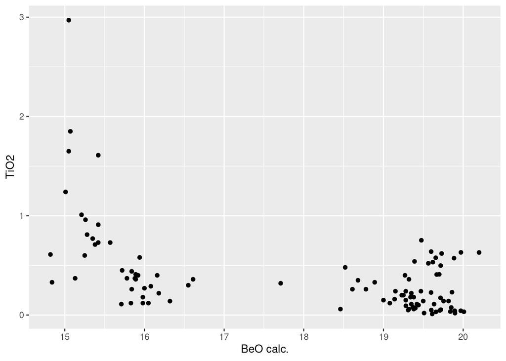

```r
library(ggplot2)

ggplot(data = initial_data_t) +
  geom_point(mapping = aes(x = `BeO calc.`, y = TiO2))
```

The structure of code is as follows:

- `ggplot()` - creates a new ggplot.
- `aes()` - constructs [aesthetic mappings](https://ggplot2.tidyverse.org/reference/aes.html). Aesthetic mappings describe how variables in the data are mapped to visual properties (aesthetics) of geoms.
- `+` - adds components to a plot.

Accordingly, a reusable template for making graphs with `ggplot2` would be:

```r
ggplot(data = <DATA>) +
  <GEOM_FUNCTION>(mapping = aes(<MAPPINGS>))
```

where

- `DATA` is a tibble or a data frame,
- `GEOM_FUNCTION` - how to visualize the data,
- `MAPPINGS` - which variables to use and how

What happens when we run `ggplot(data = initial_data_t)`?

Open the [cheat sheet](https://github.com/rstudio/cheatsheets/blob/main/data-visualization-2.1.pdf) to start exploring this library.

## 6.1 Scatter plot

### 6.1.1 A basic one

Let’s start with a simple scatter binary plot. Try to plot *TiO2* on X axis with *Al2O3* on Y axis for our dataframe!

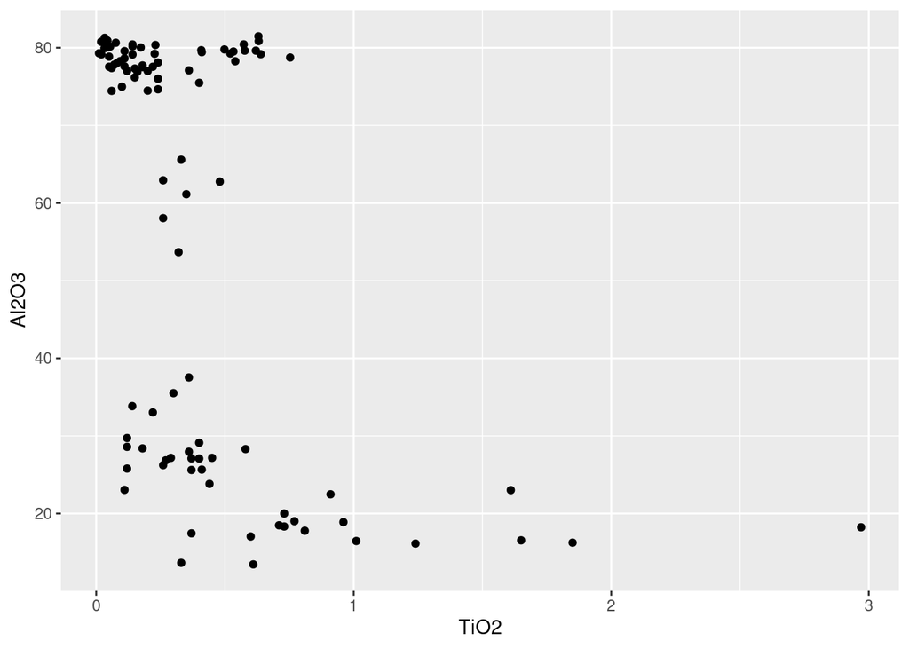

```r
ggplot(data = initial_data_t) +
  geom_point(mapping = aes(x = TiO2, y = Al2O3))
```

### 6.1.2 With custom color

Let’s change the color of the points and adjust their size:

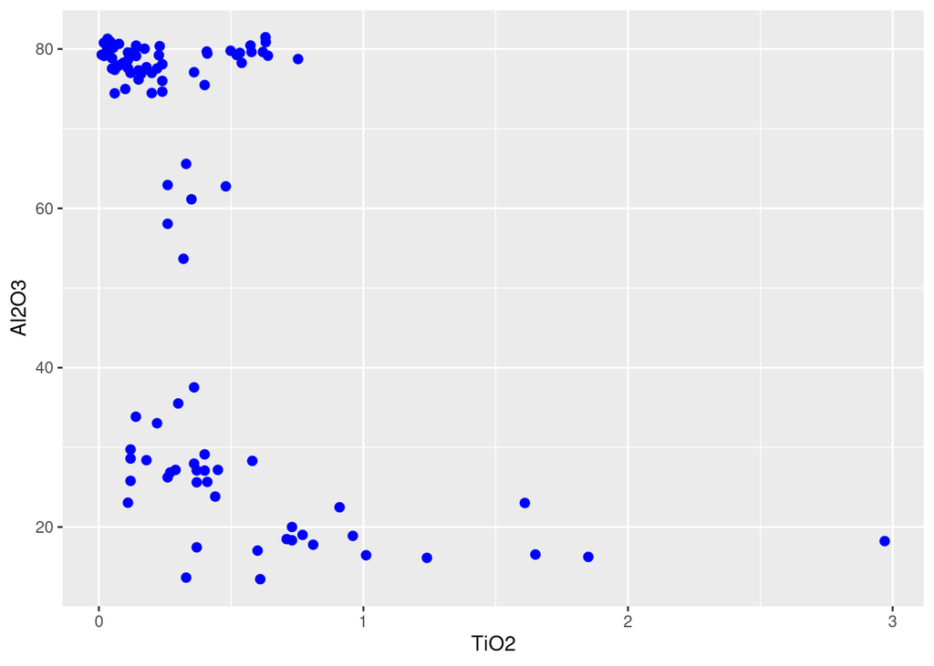

```r
ggplot(data = initial_data_t) +
  geom_point(mapping = aes(x = TiO2, y = Al2O3), color='blue', size=2)
```

### 6.1.3 With custom stroke, shape and fill

Let’s change the stroke of points, shape and a fill color:

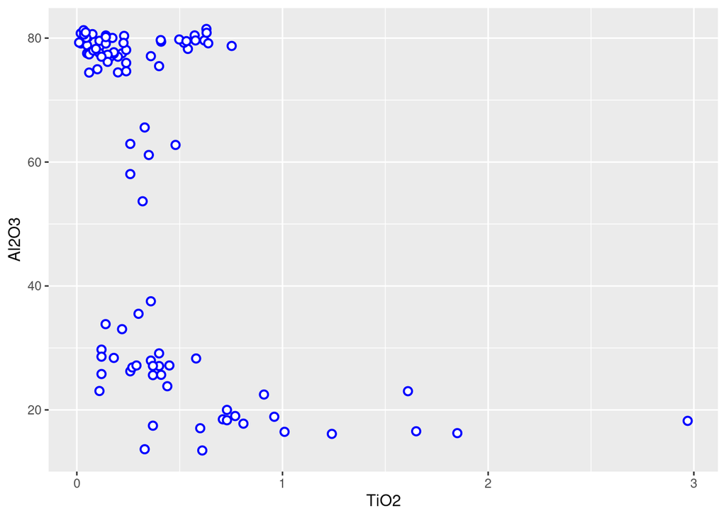

```r
ggplot(data = initial_data_t) +
  geom_point(mapping = aes(x = TiO2, y = Al2O3), shape=21, color='blue', fill='white', size=2, stroke=1)
```

You can find the available options for R shapes [here](http://sape.inf.usi.ch/quick-reference/ggplot2/shape).

### 6.1.4 With calculated colors

Let’s assign colors depending on the Origin of our samples (`Origin` column). We can control this by passing `color` argument to `aes()` function.

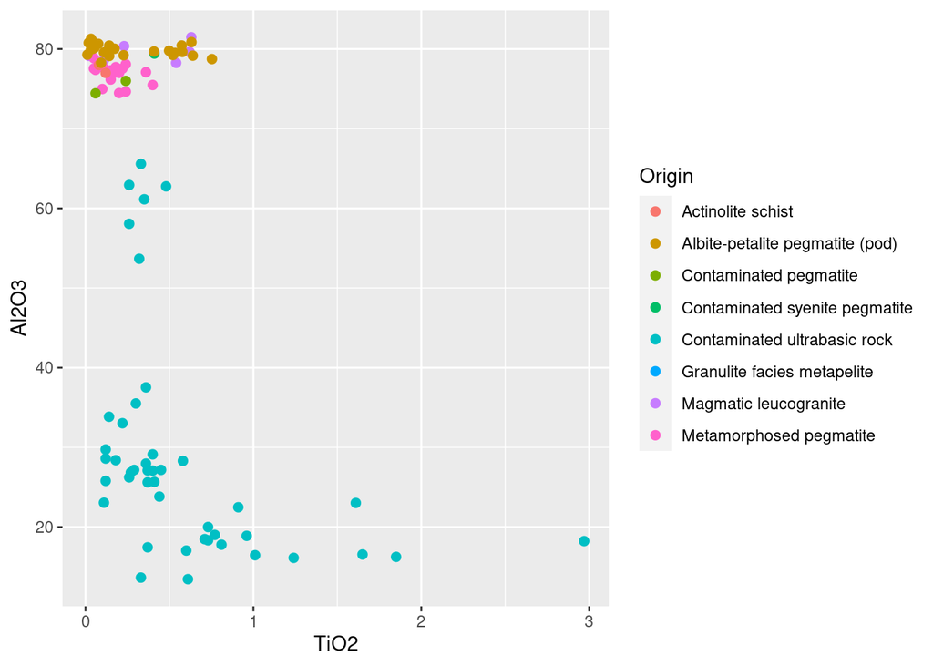

```r
ggplot(data = initial_data_t) +
  geom_point(mapping = aes(x = TiO2, y = Al2O3, color=Origin), size=2)
```

#### 6.1.4.1 Using `scale_color_brewer()`

Hmmm… you see that by default `ggplot2` assigns very similar colors to two groups - *Contaminated syenite pegmatite* and *Contaminated ultrabasic rock*. Luckily, `ggplot2` provides us with few functions to change the colors palette according to a [discrete](https://ggplot2.tidyverse.org/reference/scale_brewer.html) or a [continuous](https://ggplot2.tidyverse.org/reference/scale_colour_continuous.html) scale.

We will append a function `scale_color_brewer()` to our `ggplot2` object and see what happens!

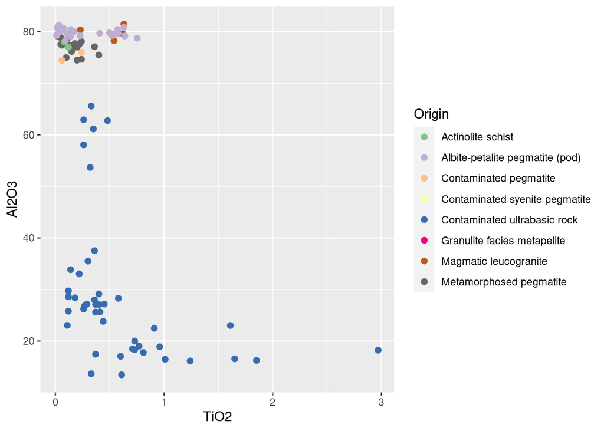

```r
ggplot(data = initial_data_t) +
  geom_point(mapping = aes(x = TiO2, y = Al2O3, color=Origin), size=2) +
  scale_color_brewer(palette = "Accent")
```

Try to pass `scale_color_brewer()` without any argument. What happens? Now, try to use another palette. You can choose the palette of your preferences from [here](https://ggplot2.tidyverse.org/reference/scale_brewer.html#palettes).

### 6.1.5 Create subplots, using `facet_wrap()`

One way to add additional variables is with aesthetics. Another way, particularly useful for **categorical variables**, is to split your plot into **facets** - *subplots that each display one subset of the data*.

To facet your plot by a single variable, use `facet_wrap()`. The first argument of `facet_wrap()` should be a formula, which you create with `~` followed by a variable name (here “formula” is the name of a data structure in R, not a synonym for “equation”). The variable that you pass to `facet_wrap()` should be discrete.

So, let’s create a separate plot for each origin, using the facets!

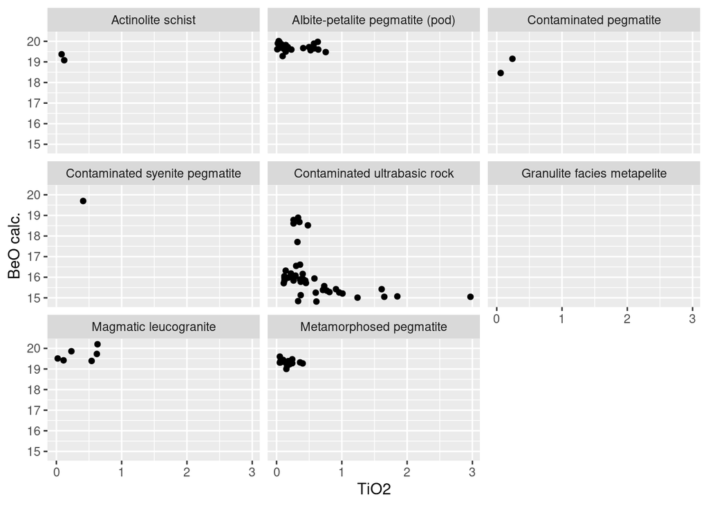

```r
ggplot(data = initial_data_t) +
  geom_point(mapping = aes(x = TiO2, y = `BeO calc.`)) +
  facet_wrap(~Origin)
```

You can even use a logical expression to create subplots. Consider an idea to create two subplots:

- BeO with TiO2 where BeO >= 18wt%
- BeO with TiO2 where BeO <= 18wt%

Here is how we can achieve that:

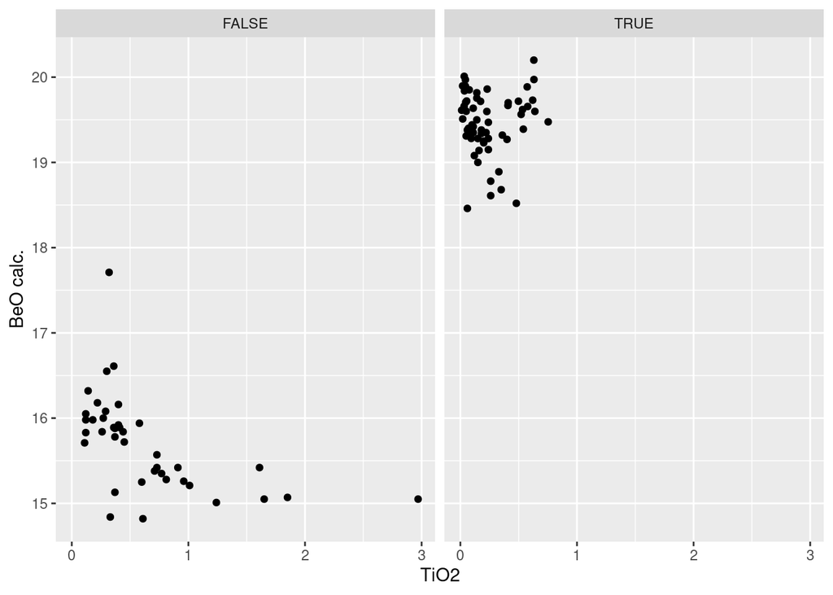

```r
ggplot(data = initial_data_t) +
  geom_point(mapping = aes(x = TiO2, y = `BeO calc.`)) +
  facet_wrap(~ `BeO calc.` >= 18)
```

## 6.2 Box plot

Often, we might want to see the spread of some data based on the group or a category. The useful visual representation of it can be a [box plot](https://r-graph-gallery.com/boxplot.html)!

### 6.2.1 A basic plot

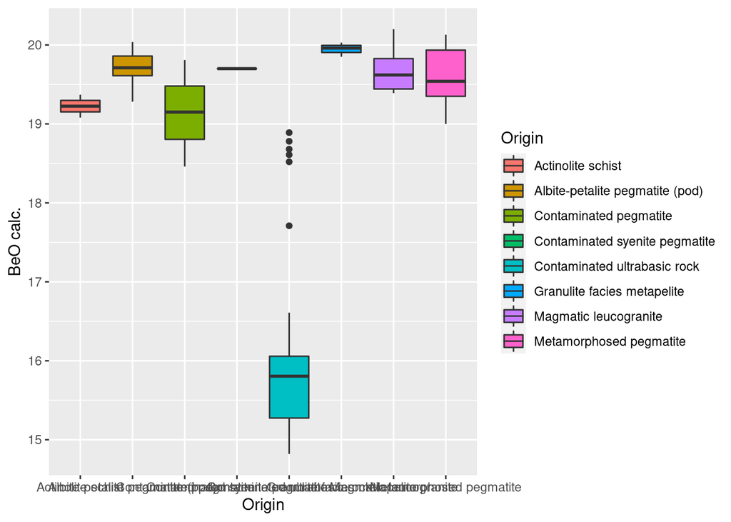

```r
ggplot(data = initial_data_t) +
  geom_boxplot(mapping = aes(x = Origin, y = `BeO calc.`, fill=Origin))
```

### 6.2.2 Improve the labels

Since we are showing the legend, perhaps we might want to remove the X axis ticks labels, as they are too long and overlap. We can control that by passing a function `scale_x_discrete()`. Additionally, lets give some pretty labels to X and Y axis using the `xlab()` and `ylab()` functions.

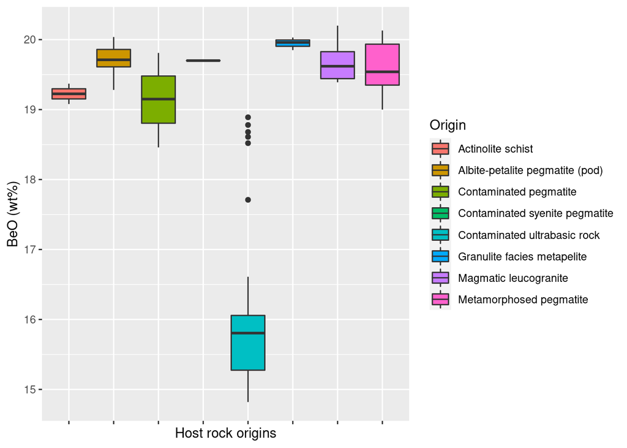

```r
ggplot(data = initial_data_t) +
  geom_boxplot(mapping = aes(x = Origin, y = `BeO calc.`, fill=Origin)) +
  scale_x_discrete(labels=NULL) +
  xlab(label="Host rock origins") +
  ylab(label='BeO (wt%)')
```

Looks better now!